# Ιεραρχική συσσωρευτική συσταδοποίηση

Leonidas Liakos

5/30/2022

Στόχος του παρόντος notebook είναι να επιδειχθεί η διαδικασία της ιεραρχικής συσσωρευτικής συσταδοποίησης (agglomerative hierarchical clustering) με την R.

Εισαγωγή των απαραίτητων βιβλιοθηκών.

```r
library(tidyverse)  # data manipulation
library(cluster)    # clustering algorithms
library(factoextra) # clustering visualization
library(dendextend) # for comparing two dendrograms
```

Χρησιμοποιούμε τα δεδομένα συλλήψεων ανά 100.000 κατοίκους για βίαιες επιθέσεις, δολοφονίες και βιασμούς για κάθε πολιτεία των ΗΠΑ το 1973.

Πρέπει να αφαιρεθούν κενά δεδομένα. Επίσης τα δεδομένα πρέπει να κανονικοποιηθούν για να είναι συγκρίσιμα.

```r
df <- USArrests
df <- na.omit(df) # αφαίρεση κενών
df <- scale(df) # scaling
```

Υπολογισμός του πίνακα αποστάσεων μεταξύ ζεύγη παρατηρήσεων. Χρησιμοποιούμε σαν απόσταση την Ευκλίδεια απόσταση. Προκύπτει ο πίνακας Ομοιότητας ή Αποστάσεων. Ο πίνακας αυτός χρησιμοποιείται στην συνέχεια ως δεδομένα εισόδου στην συνάρτηση hclust που διεξάγει την μέθοδο ιεραρχικής συσταδοποίησης. Επιπλέον σε αυτήν την συνάρτηση ορίζεται και ο τρόπος μέτρησης των αποστάσεων ανάμεσα στις ομάδες, στην περίπτωσή μας ορίστηκε σε Complete Linkage. Ακολουθεί η οπτικοποίηση της συσταδοποίησης σε δενδρόγραμμα.

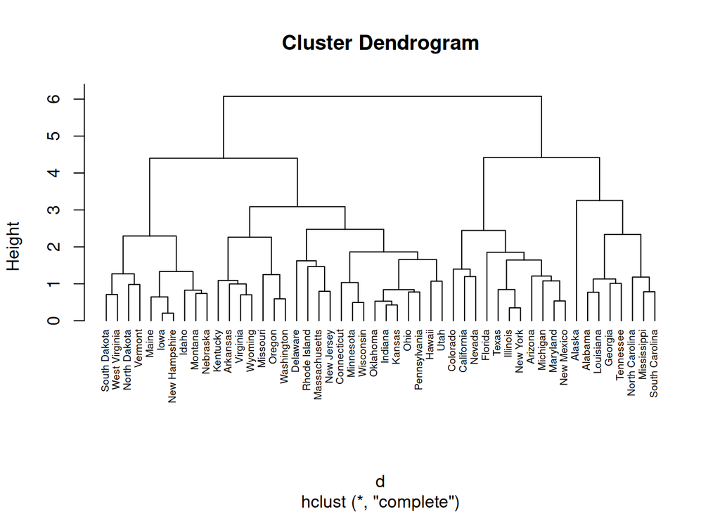

```r
# Dissimilarity matrix
d <- dist(df, method = "euclidean")

# Hierarchical clustering using Complete Linkage
hc1 <- hclust(d, method = "complete" )

# Plot the obtained dendrogram
plot(hc1, cex = 0.6, hang = -1)
```

Εναλλακτικά μπορούμε να ορίσουμε διαφορετική μέθοδο υπολογισμού των αποστάσεων όπως η μέθοδος Ward’s. Μπορούμε να κατατμήσουμε το δενδρόγραμμα σε 4 συστάδες, να δείξουμε το αντίστοιχο δενδρόγραμμα και να πάρουμε το πλήθος των παρατηρήσεων ανά συστάδα.

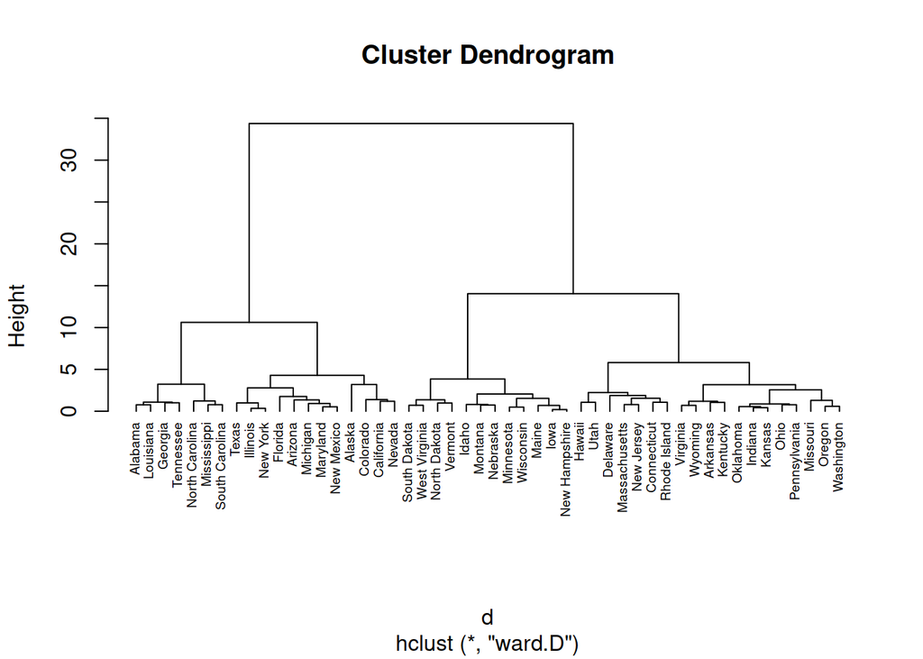

```r
# Ward's method
hc2 <- hclust(d, method = "ward.D" )

# Cut tree into 4 groups
sub_grp <- cutree(hc2, k = 4)

# Plot the obtained dendrogram
plot(hc2, cex = 0.6, hang = -1)
```

```r
# Number of members in each cluster
table(sub_grp)
```

```
## sub_grp
##  1  2  3  4
##  7 12 19 12
```

Επιπλέον μπορούμε να οριοθετήσουμε στο δενδρόγραμμα με περίγραμμα τις συστάδες.

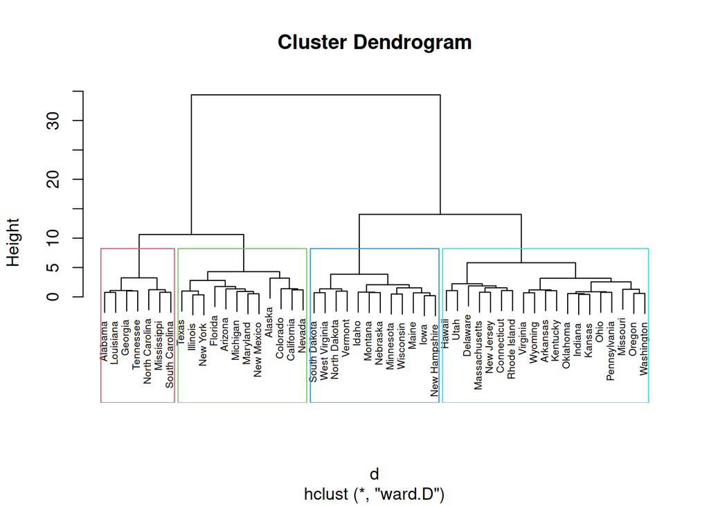

```r
plot(hc2, cex = 0.6)
rect.hclust(hc2, k = 4, border = 2:5)
```

Μπορούμε να ορίσουμε στον αρχικό πίνακα την συστάδα στην οποία ανήκει η κάθε πολιτεία.

```r
USArrests %>%
  mutate(cluster = sub_grp) %>%
  head
```

```
##            Murder Assault UrbanPop Rape cluster
## Alabama      13.2     236       58 21.2       1
## Alaska       10.0     263       48 44.5       2
## Arizona       8.1     294       80 31.0       2
## Arkansas      8.8     190       50 19.5       3
## California    9.0     276       91 40.6       2
## Colorado      7.9     204       78 38.7       2
```

Τέλος έχουμε την δυνατότητα να οπτικοποιήσουμε την ιεράρχηση σε διάγραμμα διασποράς.

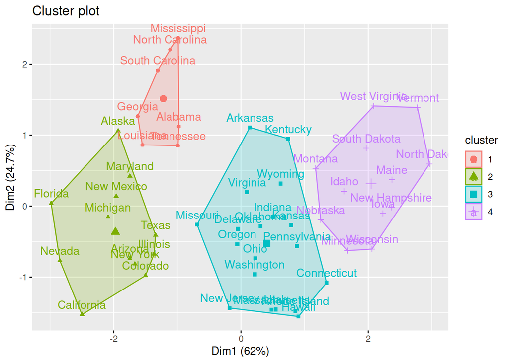

```r
fviz_cluster(list(data = df, cluster = sub_grp))
```